# Plots_and_Analyses.R

#### Basic PSA Screening Model

Since I’m going to use PSA Screening a lot, I’m also going to make a model for that here. I’m going to use the continuous IQR-step model since that is the broadest and usable for a nearby presentation

```r
# Set up
data_controls = data_df %>% filter(prostate_case == 0) %>% mutate(PSA_Screening = as.factor(PSA_Screening))
keep_variables = c("data_df", "data_controls", "keep_variables", "ses_factors",
                   "ances", "ances_exclude")
rm(list = ls()[!(ls() %in% keep_variables)])


# Create some dataframes to save the prevalence per ancestry
summ_df = tibble()

# I also want to loop through this per ancestry
for (j in ances_exclude){

    # Print ancestry to benchmark
    print(j)

    # Let's pull out the ancestry specific data and set list for models for this ancestry
    data_split = data_controls %>% filter(Ances == j)
    model_results = list()

  for (i in ses_factors){

    # Create the total cases model for the ses, edit the output, and then save in the list
      formula = paste0("PSA_Screening ~", i, " + age_assessment") %>% as.formula()
      model = logistic_reg() %>% fit(formula, data = data_split)

    #I also want to adjust the beta to account for a IQR change so I need to do some manipulation
      ses_iqr = data_df %>% pull(i) %>% IQR(na.rm = T)

        # Compared to other models, I don't log the estimate because I didn't previously exponentiate it
        OR = tidy(model) %>%
          mutate(estimate = ses_iqr*estimate,
                 std.error = ses_iqr*std.error) %>%
          mutate(OR = exp(estimate),
                 low95 = exp(estimate - 1.96*std.error),
                 up95 = exp(estimate + 1.96*std.error)) %>%
          select(-std.error, -statistic, -estimate) %>%
          select(term, OR, p.value, low95, up95)

    model_results[[i]] <- OR

    # Benchmark that this set of model is complete
    print(i)
  }

  # Save the models
  results_df = list_rbind(model_results, names_to = "ses")

  # Then add to summary data_frame
  summ_df = results_df %>%
    mutate(ancestry = j) %>%
    rbind(summ_df, .)

}
```

```
[1] "eur"
[1] "IMD"
[1] "Income"
[1] "Employment"
[1] "Health"
[1] "Education"
[1] "Housing"
[1] "Crime"
[1] "Environment"
[1] "Townsend_Index"
[1] "afr"
[1] "IMD"
[1] "Income"
[1] "Employment"
[1] "Health"
```

[output cut: 25 more lines]

```r
# And write
summ_df %>%
  write_csv( file = "/labs/jswitte/Projects/jjudd5/SES.PRS_Project/SES_Models/PSA_outcome_ses_models_2023.11.28.csv")
```

And then the basic plots

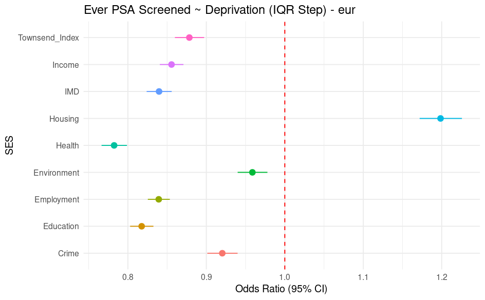

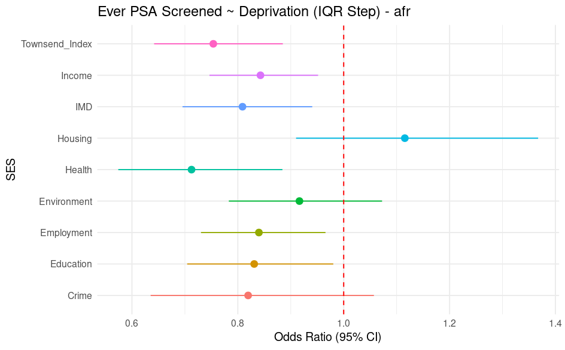

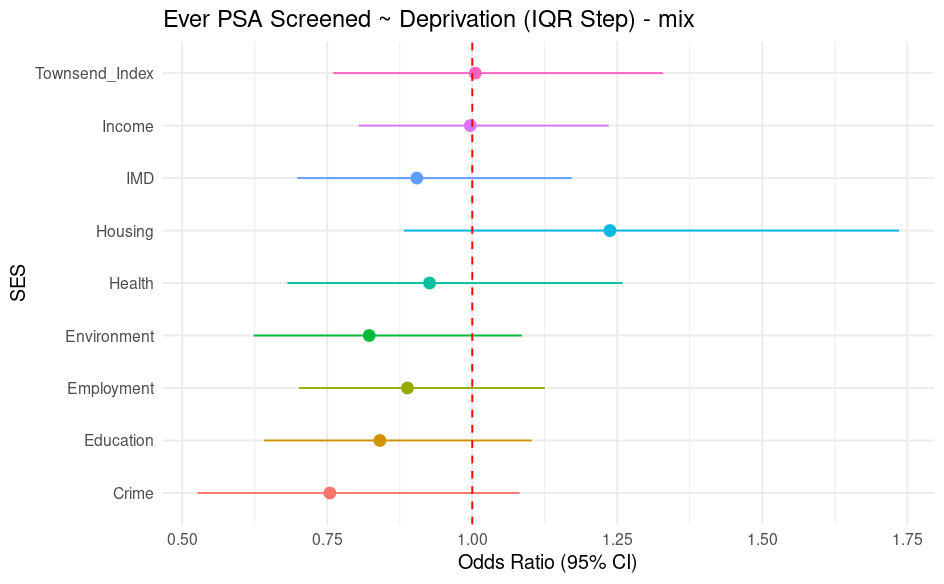

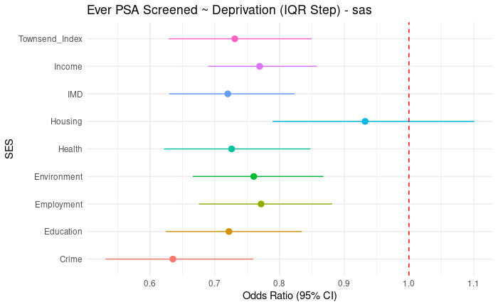

```r
# Edit this df to better plot
`%notin%` = Negate(`%in%`) # Quick helper function

for (j in ances_exclude){

  plotting_df = summ_df %>%
    filter(ancestry == j) %>%
    filter(term %notin% c("(Intercept)", "age_assessment")
           )

  # Create a plot
  p = plotting_df %>%
        ggplot(aes(x = OR, y = ses, xmin = low95, xmax = up95, color = ses)) +
        geom_pointrange(show.legend = FALSE) +
        geom_vline(xintercept = 1, linetype = "dashed", color = "red") +
        labs(x = "Odds Ratio (95% CI)", y = "SES") +
        ggtitle(paste0("Ever PSA Screened ~ Deprivation (IQR Step) - ", j)
                ) +
        theme_minimal()

  print(p)

}
```

#### Basic PRS Model

Since I’m using a new 451 variant model, I’m going to run a new basic PRS model since my expected results are going to be slightly different. With this, I will compare the separate ancestries PRS ORs since that is the one comparison

```r
# Set up
keep_variables = c("data_df", "keep_variables", "ses_factors",
                   "ances", "ances_exclude")
rm(list = ls()[!(ls() %in% keep_variables)])


# Create some dataframes to save the prevalence per ancestry
summ_df = tibble()

# I also want to loop through this per ancestry
for (j in ances_exclude){

  # Print ancestry to benchmark
  print(j)

  # Let's pull out the ancestry specific data and set list for models for this ancestry
  data_split = data_df %>% filter(Ances == j)
  model_results = list()


  # Create the total cases model for the ses, edit the output, and then save in the list
    formula = paste0("prostate_case ~ PRS + age_assessment + PSA_Screening",
                     str_flatten(str_c("+ PC",1:10))
                     ) %>%
                       as.formula()
    model = logistic_reg() %>% fit(formula, data = data_split)

    # Compared to other models, I don't log the estimate because I didn't previously exponentiate it
    OR = tidy(model, exponentiate = T) %>%
      rename(OR = estimate) %>%
      mutate(low95 = exp(log(OR) - 1.96*std.error),
             up95 = exp(log(OR) + 1.96*std.error)) %>%
      select(-std.error, -statistic)

  model_results <- OR

  # Add to summary data_frame with the ancestry
  summ_df = model_results %>%
    mutate(ancestry = j) %>%
    rbind(summ_df, .)

}
```

```
[1] "eur"
[1] "afr"
[1] "mix"
[1] "sas"
```

```r
# And write
summ_df %>%
  write_csv( file = "/labs/jswitte/Projects/jjudd5/SES.PRS_Project/SES_Models/PRSonly_models_2023.11.28.csv")
```

Now plot the different PRS results

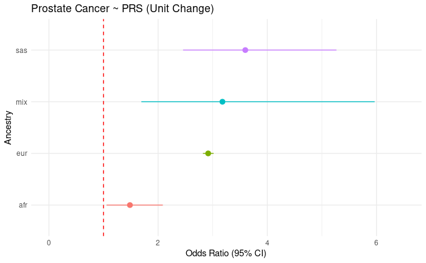

```r
# Edit this df to better plot
plotting_df = summ_df %>%
  filter(term %in% "PRS"
         )

# Create a plot
plotting_df %>%
  ggplot(aes(x = OR, y = ancestry, xmin = low95, xmax = up95, color = ancestry)) +
  geom_pointrange(show.legend = FALSE) +
  geom_vline(xintercept = 1, linetype = "dashed", color = "red") +
  labs(x = "Odds Ratio (95% CI)", y = "Ancestry") +
  ggtitle(paste0("Prostate Cancer ~ PRS (Unit Change)")
          ) +
  xlim(0,6.5) +
  theme_minimal()
```

#### SES*PRS Interaction Model

The last model I am going to generate is the model that looks at the interaction between SES and PRS scores. I’m going to use the IQR base model as the SES variable and also keep the unit change PRS model

```r
keep_variables = c("data_df", "keep_variables", "ses_factors",
                   "ances","ances_exclude")
rm(list = ls()[!(ls() %in% keep_variables)])


# Create some dataframes to save the prevalence per ancestry
summ_df = tibble()

# I also want to loop through this per ancestry
for (j in ances_exclude){

    # Print ancestry to benchmark
    print(j)

    # Let's pull out the ancestry specific data and set list for models for this ancestry
    data_split = data_df %>% filter(Ances == j)
    model_results = list()

  # Now create a loop that models the variables of interest and then saves them to a list of models
  for (i in ses_factors){

      # Run models of interest
      formula = paste0("prostate_case ~ ",i, " + PRS + PRS*", i,
                       " + age_assessment + PSA_Screening", str_flatten(str_c("+ PC",1:10))
                       ) %>% as.formula()

      model = logistic_reg() %>% fit(formula, data = data_split)

      # I also want to adjust the beta to account for a IQR change so I need to do some manipulation
      ses_iqr = data_df %>% pull(i) %>% IQR(na.rm = T)

      # Compared to other models, I don't log the estimate because I didn't previously exponentiate it
      # Though i want to calculate the ORs differently so I need multiple model corrections. 1 for the SES variable
      OR_ses = tidy(model) %>%
        mutate(estimate = ses_iqr*estimate,
               std.error = ses_iqr*std.error) %>%
        mutate(OR = exp(estimate),
               low95 = exp(estimate - 1.96*std.error),
               up95 = exp(estimate + 1.96*std.error)) %>%
        select(-std.error, -statistic, -estimate) %>%
        select(term, OR, p.value, low95, up95) %>%
        .[c(2,16),]


      # And one for the PRS variable
      OR_prs = tidy(model, exponentiate = T) %>%
      rename(OR = estimate) %>%
      mutate(low95 = exp(log(OR) - 1.96*std.error),
             up95 = exp(log(OR) + 1.96*std.error)) %>%
      select(-std.error, -statistic) %>%
        .[3,]

      # Then merge the 2
      OR = rbind(OR_ses, OR_prs)

      model_results[[i]] <- OR

      # Benchmark that this set of model is complete
      print(i)
  }

  # Save the models
  results_df = list_rbind(model_results, names_to = "ses")

  # Then add to summary data_frame
  summ_df = results_df %>%
    mutate(ancestry = j) %>%
    rbind(summ_df, .)

}
```

```
[1] "eur"
[1] "IMD"
[1] "Income"
[1] "Employment"
[1] "Health"
[1] "Education"
[1] "Housing"
[1] "Crime"
[1] "Environment"
[1] "Townsend_Index"
[1] "afr"
[1] "IMD"
[1] "Income"
[1] "Employment"
[1] "Health"
```

[output cut: 25 more lines]

```r
# And now export these models.
summ_df %>% write_csv( file = "/labs/jswitte/Projects/jjudd5/SES.PRS_Project/SES_Models/Interaction_ses_models_2023.11.28.csv")
```

Now plot the results. I’m going to make 3 plots for each of the 3 results I care about: - SES Main Effect - PRS Main Effect - SES*PRS Interaction Effect

```
[1] "eur"
[1] "afr"
[1] "mix"
[1] "sas"
```

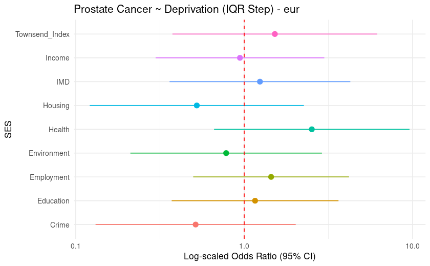

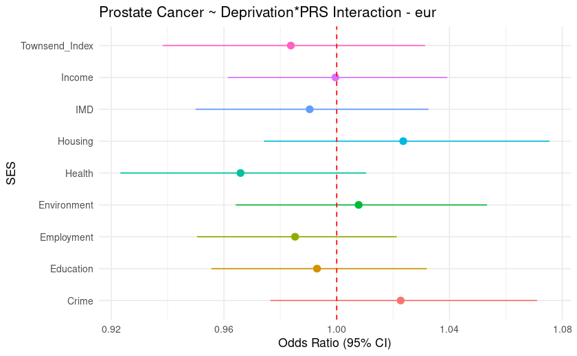

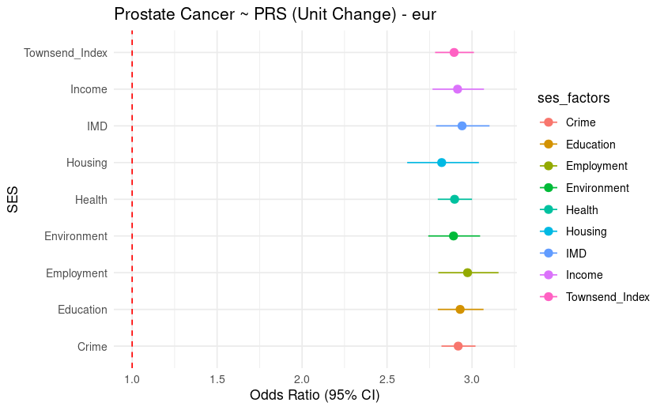

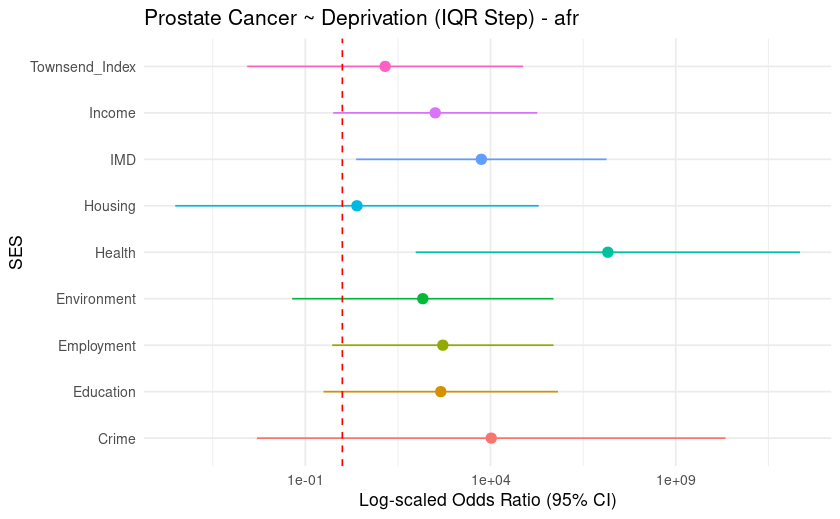

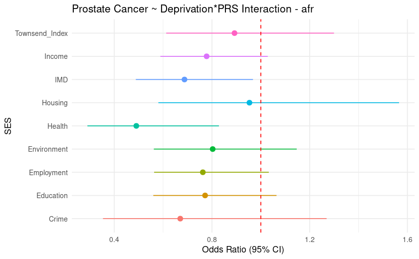

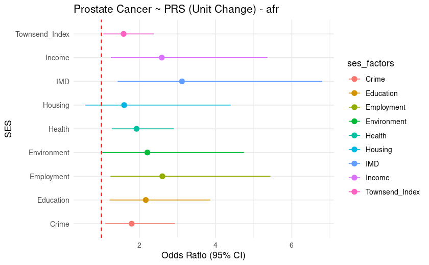

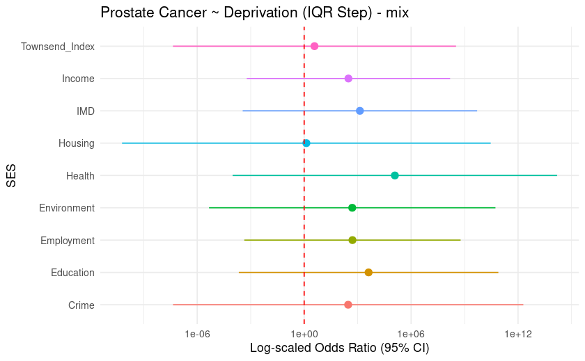

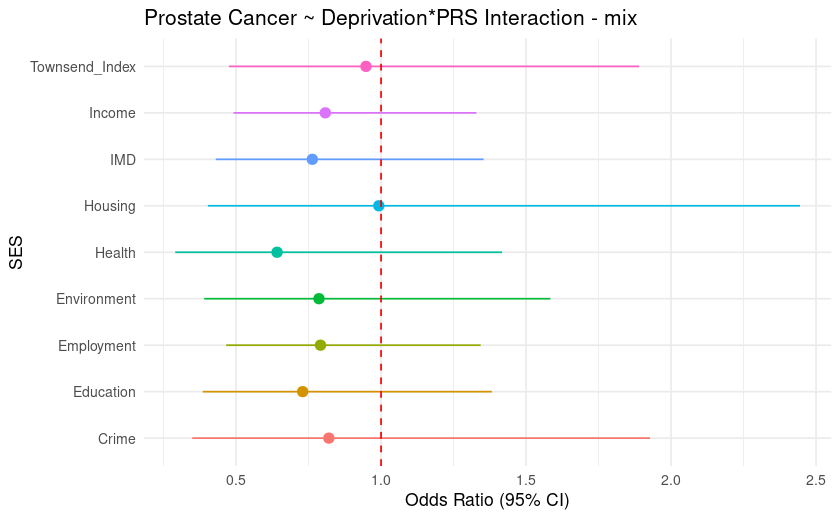

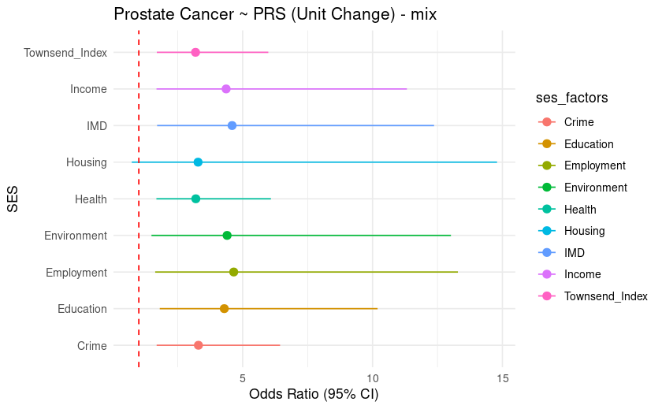

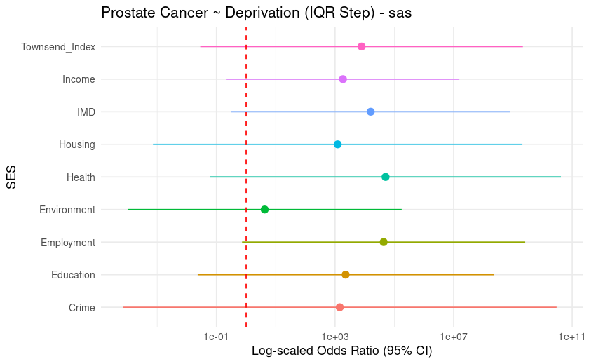

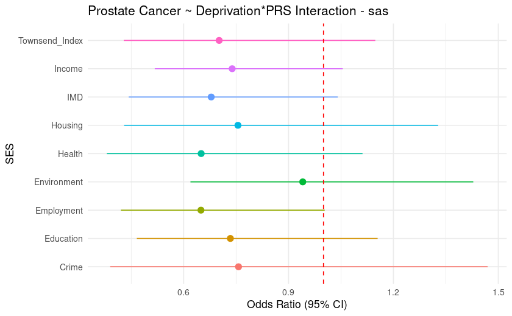

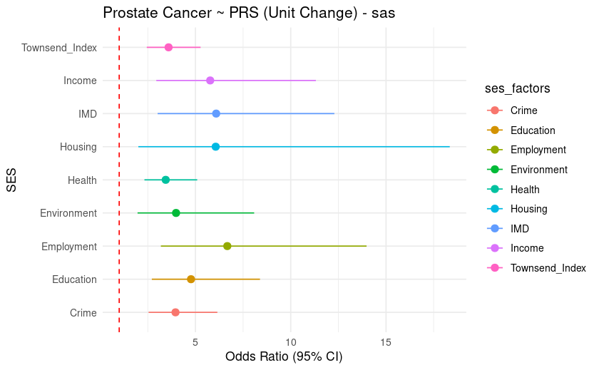

```r
# Edit this df to better plot
`%notin%` = Negate(`%in%`) # Quick helper function

for (j in ances_exclude){

  print(j)

  plotting_df = summ_df %>%
    filter(ancestry == j)

  # Create a plot
  ses_plot = plotting_df %>% filter(str_detect(term, "PRS",negate = T)) %>%
                ggplot(aes(x = OR, y = ses, xmin = low95, xmax = up95, color = ses_factors)
                       ) +
                geom_pointrange(show.legend = FALSE) +
                geom_vline(xintercept = 1, linetype = "dashed", color = "red") +
                scale_x_log10() +
                labs(x = "Log-scaled Odds Ratio (95% CI)", y = "SES") +
                ggtitle(paste0("Prostate Cancer ~ Deprivation (IQR Step) - ", j)
                        )+
                theme_minimal()

  int_plot = plotting_df %>% filter(str_detect(term, ":")) %>%
                ggplot(aes(x = OR, y = ses, xmin = low95, xmax = up95, color = ses_factors)
                       ) +
                geom_pointrange(show.legend = FALSE) +
                geom_vline(xintercept = 1, linetype = "dashed", color = "red") +
                labs(x = "Odds Ratio (95% CI)", y = "SES") +
                ggtitle(paste0("Prostate Cancer ~ Deprivation*PRS Interaction - ", j)
                        )+
                theme_minimal()

  prs_plot = plotting_df %>% filter(str_detect(term, "PRS"), str_detect(term, ":", negate = T)) %>%
              ggplot(aes(x = OR, y = ses, xmin = low95, xmax = up95, color = ses_factors)) +
              geom_pointrange(show.legend = T) +
              geom_vline(xintercept = 1, linetype = "dashed", color = "red") +
              labs(x = "Odds Ratio (95% CI)", y = "SES") +
              ggtitle(paste0("Prostate Cancer ~ PRS (Unit Change) - ", j)
                      ) +
              theme_minimal()

  print(ses_plot)
  print(int_plot)
  print(prs_plot)

}
```

#### SES*PRS No Interaction Model

My previous interaction model is proving to be a bit funky and I think that has to do with the interaction term that I have. I want to make new models that include PRS and SES, but not the interaction term

The code will be identical except for the removal of that term

```r
keep_variables = c("data_df", "keep_variables", "ses_factors",
                   "ances","ances_exclude")
rm(list = ls()[!(ls() %in% keep_variables)])


# Create some dataframes to save the prevalence per ancestry
summ_df = tibble()

# I also want to loop through this per ancestry
for (j in ances_exclude){

    # Print ancestry to benchmark
    print(j)

    # Let's pull out the ancestry specific data and set list for models for this ancestry
    data_split = data_df %>% filter(Ances == j)
    model_results = list()

  # Now create a loop that models the variables of interest and then saves them to a list of models
  for (i in ses_factors){

      # Run models of interest
      formula = paste0("prostate_case ~ ",i, " + PRS + age_assessment + PSA_Screening", str_flatten(str_c("+ PC",1:10))
                       ) %>% as.formula()

      model = logistic_reg() %>% fit(formula, data = data_split)

      # I also want to adjust the beta to account for a IQR change so I need to do some manipulation
      ses_iqr = data_df %>% pull(i) %>% IQR(na.rm = T)

      # Compared to other models, I don't log the estimate because I didn't previously exponentiate it
      # Though i want to calculate the ORs differently so I need multiple model corrections. 1 for the SES variable
      OR_ses = tidy(model) %>%
        mutate(estimate = ses_iqr*estimate,
               std.error = ses_iqr*std.error) %>%
        mutate(OR = exp(estimate),
               low95 = exp(estimate - 1.96*std.error),
               up95 = exp(estimate + 1.96*std.error)) %>%
        select(-std.error, -statistic, -estimate) %>%
        select(term, OR, p.value, low95, up95) %>%
        .[2,]


      # And one for the PRS variable
      OR_prs = tidy(model, exponentiate = T) %>%
      rename(OR = estimate) %>%
      mutate(low95 = exp(log(OR) - 1.96*std.error),
             up95 = exp(log(OR) + 1.96*std.error)) %>%
      select(-std.error, -statistic) %>%
        .[3,]

      # Then merge the 2
      OR = rbind(OR_ses, OR_prs)

      model_results[[i]] <- OR

      # Benchmark that this set of model is complete
      print(i)
  }

  # Save the models
  results_df = list_rbind(model_results, names_to = "ses")

  # Then add to summary data_frame
  summ_df = results_df %>%
    mutate(ancestry = j) %>%
    rbind(summ_df, .)

}
```

```
[1] "eur"
[1] "IMD"
[1] "Income"
[1] "Employment"
[1] "Health"
[1] "Education"
[1] "Housing"
[1] "Crime"
[1] "Environment"
[1] "Townsend_Index"
[1] "afr"
[1] "IMD"
[1] "Income"
[1] "Employment"
[1] "Health"
```

[output cut: 25 more lines]